# 数学建模

### 模型知识点

### 优化模型-图论模型-最小生成树

**Wang Haihua**

🚅 🚋😜 🚑 🚔

最小生成树（MST）是图论中的基本问题，具有广泛的实际应用，在数学建模中也经常出现。 路线设计、道路规划、官网布局、公交路线、网络设计，都可以转化为最小生成树问题，如要求总线路长度最短、材料最少、成本最低、耗时最小。 最小生成树的典型算法有普里姆算法（Prim算法）和克鲁斯卡算法（Kruskal算法）.

## 1. 最小生成树

### 1.1 生成树

**树是图论中的基本概念。连通的无圈图称为树（Tree），就是不包含循环的回路的连通图。**

**生成树满足：（1）包含连通图中所有的顶点；（2）任意两顶点之间有且仅有一条通路。因此，生成树中边的数量 = 顶点数 - 1。**

对于非连通无向图， 遍历每个连通分量中的顶点集合所经过的边是多颗生成树，这些连通分量的生成树构成非连通图的生成森林 。

### 1.2 最小生成树和最大生成树

遍历连通图的方式通常有很多种，也就是说一张连通图可能有多种不同的生成树。

无向赋权图的生成树中，各条边的**权重之和最小的生成树，称为最小生成树（minimum spanning tree，MST），也称最小权重生成树。**

对应地，**各条边的权重之和最大的生成树，称为最大生成树（maximum spanning tree）。**

### 1.3 最小生成树问题

最小生成树（MST）是图论中的基本问题，具有广泛的实际应用，在数学建模中也经常出现。

例如，在若干城市之间铺设通信线路，使任意两个城市之间都可以通信，要使铺设线路的总费用最低，就需要找到最小生成树。类似地，路线设计、道路规划、官网布局、公交路线、网络设计，都可以转化为最小生成树问题，如要求总线路长度最短、材料最少、成本最低、耗时最小等。

在实际应用中，不仅要考虑网络连通，还要考虑连通网络的质量和效率，就形成了带有约束条件的最小生成树：

**直径限制最小生成树（Bounded diameter minimum spanning tree）：对给定的连通图，满足直径限制的生成树中，具有最小权的树，称为直径限制最小生成树。直径限制最小生成树问题在资源优化问题中应用广泛，如网络设计的网络直径影响到网络的传输速度、效率和能耗。**

**度限制最小生成树（Degree constrained minimum spanning tree）：对给定的连通图，满足某个节点或全部节点的度约束（如入度不超过 k）的生成树中，具有最小权的树，称为度限制最小生成树。实际应用中，为了控制节点故障对整个系统的影响，需要对节点的度进行限制。**

## 2. 最小生成树算法

构造最小生成树的算法很多，通常是从空树开始，按照贪心法逐步选择并加入 n-1 条安全边（不产生回路），最终得到最小生成树。

最小生成树的典型算法有普里姆算法（Prim算法）和克鲁斯卡算法（Kruskal算法）。

### 2.1 普里姆算法（Prim算法）

Prim 算法以顶点为基础构造最小生成树，每个顶点只与连通图连接一次，因此不用考虑在加入顶点的过程中是否会形成回路。

**算法从某一个顶点 s 开始，每次选择剩余的代价最小的边所对应的顶点，加入到最小生成树的顶点集合中，逐步扩充直到包含整个连通网的所有顶点，可以称为“加点法”。**

Prim 算法中图的存贮结构采用邻接矩阵，使用一个顶点集合 u 构造最小生成树。由于不断向集合u中加点，还需要建立一个辅助数组来同步更新最小代价边的信息。

Prim 算法每次选择顶点时，都需要进行排序，但每次都只需要对一部分边进行排序。Prim 算法的时间复杂度为 O(n*n)，与边的数量无关，适用于边很多的稠密图。

采用堆实现优先队列来维护最小点，可以将Prim算法的时间复杂度降低到 O(mlogn)，称为Prim_heap 算法，但该算法的空间消耗很大。

### 2.2 克鲁斯卡算法（Kruskal算法）

**Kruskal 算法以边为基础构造最小生成树，利用避圈思想，每次找到不使图构成回路的代价最小的边。**

算法初始边数为 0，每次选择一条满足条件的最小代价边，加入到边集合中，逐步扩充直到包含整个生成树，可以称为“加边法”。

Kruskal 算法中图的存贮结构采用边集数组，权值相等的边在数组中的排列次序是任意的。Kruskal算法开始就要对所有的边进行排序，之后还需要对所有边应用 Union-Find算法，但不再需要排序。

Kruskal 算法的时间复杂度为 O(mlogm)，主要是对边排序的时间复杂度，适用于边较少的稀疏图。

## 3. NetworkX 的最小生成树算法

### 3.2 minimum_spanning_tree() 使用说明

`minimum_spanning_tree(G, weight='weight', algorithm='kruskal', ignore_nan=False)`

`minimum_spanning_edges(G, algorithm='kruskal', weight='weight', keys=True, data=True, ignore_nan=False)`

`minimum_spanning_tree()` 用于计算无向连通图的最小生成树（森林）。`minimum_spanning_edges()` 用于计算无向连通图的最小生成树（森林）的边。 对于连通无向图，计算最小生成树；对于非连通无向图，计算最小生成森林。

主要参数：

G(undirected graph)：无向图。 weight(str)：指定用作计算权重的边属性。 algorithm(string)：计算最小生成树的算法，可选项为 'kruskal'、'prim' 或 'boruvka'。默认算法为 'kruskal'。 data(bool)：指定返回值是否包括边的权值。 ignore_nan(bool) ：在边的权重为 Nan 时产生异常。 返回值：

`minimum_spanning_tree()` 的返回值是由最小生成树构成的图，类型为 NetworkX Graph，需要用 T.edges() 获得对应的最小生成树的边。 `minimum_spanning_edges()` 的返回值是最小生成树的构成边，类型为<class 'generator'>，需要用 list() 转换为列表数据。

### 3.3 案例：天然气管道铺设问题

问题描述：

[figure not shown]

程序说明：

这是一个最小生成树问题，用 NetworkX 的 `minimum_spanning_tree()` 函数即可求出费用最小的管道路线。

图的输入。本例为稀疏的有权无向图，使用 G.add_weighted_edges_from() 函数以列表向图中添加多条赋权边，每个赋权边以元组 (node1,node2,weight) 表示。 `nx.minimum_spanning_tree()` 和 `nx.tree.minimum_spanning_edges()` 都可以计算最小生成树，参数设置和属性也基本一致，区别主要在于返回值的格式和调用方式。 Python 例程：

```python
import numpy as np
import matplotlib.pyplot as plt # 导入 Matplotlib 工具包
import networkx as nx  # 导入 NetworkX 工具包

# 1. 天然气管道铺设
G1 = nx.Graph()  # 创建：空的 无向图
G1.add_weighted_edges_from([(1,2,5),(1,3,6),(2,4,2),(2,5,12),(3,4,6),
                (3,6,7),(4,5,8),(4,7,4),(5,8,1),(6,7,5),(7,8,10)])  # 向图中添加多条赋权边: (node1,node2,weight)

T = nx.minimum_spanning_tree(G1)  # 返回包括最小生成树的图
print(T.nodes)  # 最小生成树的 顶点
print(T.edges)  # 最小生成树的 边
print(sorted(T.edges)) # 排序后的 最小生成树的 边
print(sorted(T.edges(data=True)))  # data=True 表示返回值包括边的权重

mst1 = nx.tree.minimum_spanning_edges(G1, algorithm="kruskal") # 返回最小生成树的边
print(list(mst1))  # 最小生成树的 边
mst2 = nx.tree.minimum_spanning_edges(G1, algorithm="prim",data=False)  # data=False 表示返回值不带权
print(list(mst2))
```

```
[1, 2, 3, 4, 5, 6, 7, 8]
[(1, 2), (1, 3), (2, 4), (4, 7), (4, 5), (5, 8), (6, 7)]
[(1, 2), (1, 3), (2, 4), (4, 5), (4, 7), (5, 8), (6, 7)]
[(1, 2, {'weight': 5}), (1, 3, {'weight': 6}), (2, 4, {'weight': 2}), (4, 5, {'weight': 8}), (4, 7, {'weight': 4}), (5, 8, {'weight': 1}), (6, 7, {'weight': 5})]
[(5, 8, {'weight': 1}), (2, 4, {'weight': 2}), (4, 7, {'weight': 4}), (1, 2, {'weight': 5}), (6, 7, {'weight': 5}), (1, 3, {'weight': 6}), (4, 5, {'weight': 8})]
[(1, 2), (2, 4), (4, 7), (7, 6), (1, 3), (4, 5), (5, 8)]
```

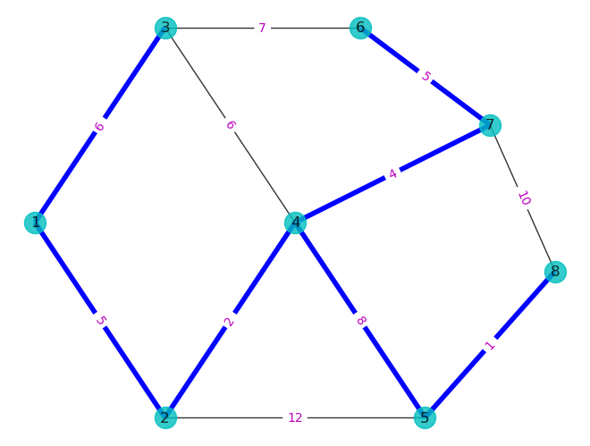

```python
# 绘图
pos={1:(1,5),2:(3,1),3:(3,9),4:(5,5),5:(7,1),6:(6,9),7:(8,7),8:(9,4)}  # 指定顶点位置
nx.draw(G1, pos, with_labels=True, node_color='c', alpha=0.8)  # 绘制无向图
labels = nx.get_edge_attributes(G1,'weight')
nx.draw_networkx_edge_labels(G1,pos,edge_labels=labels, font_color='m') # 显示边的权值
nx.draw_networkx_edges(G1,pos,edgelist=T.edges,edge_color='b',width=4)  # 设置指定边的颜色
plt.show()
```

## 4. 案例：建设通信网络

### 4.1 问题描述

在 n 个城市架设 n-1 条线路，建设通信网络。任意两个城市之间都可以建设通信线路，且单位长度的建设成本相同。求建设通信网络的最低成本的线路方案。

（1）城市数，由键盘输入； （2）城市坐标 x, y 在（0～100）之间随机生成； （3）输出线路方案的各段线路及长度。

### 4.2 程序说明

这是一个典型的最小生成树问题。n 个城市构成图的 n 个顶点，任意两个顶点之间都有连接边，边的权值是两个顶点的间距。 nx.complete_graph(n) 可以创建一个全连接图，即任意两个顶点之间都有连接边。

### 4.3 Python 例程

```python
import numpy as np
import matplotlib.pyplot as plt # 导入 Matplotlib 工具包
import networkx as nx  # 导入 NetworkX 工具包
from scipy.spatial.distance import pdist, squareform

# # 2. 城市通信网络建设
# nCities = input("Input number of cities (n>=10):")
# nCities = int(nCities)
nCities = 20
np.random.seed(1)
xPos = np.random.randint(0, 100, nCities)  # 生成 [0,100) 均匀分布的随机整数
yPos = np.random.randint(0, 100, nCities)  # 生成 Ncities 个城市坐标
```

```python
posCity = []
G2 = nx.complete_graph(nCities)  # 创建：全连接图
for node in G2.nodes():
    G2.add_node(node, pos=(xPos[node], yPos[node]))  # 向节点添加位置属性 pos
    posCity.append(G2.nodes[node]["pos"])  # 获取节点位置属性 pos

dist = squareform(pdist(np.array(posCity)))  # 计算所有节点之间的距离
for u, v in G2.edges:
    G2.add_edge(u, v, weight=np.round(dist[u][v],decimals=1))  # 向边添加权值 dist(u,v)

T = nx.minimum_spanning_tree(G2, algorithm='kruskal')  # 返回包括最小生成树的图
print("\n城市位置:\n",G2._node)
print("\n通信网络:\n",sorted(T.edges(data=True)))  # data=True 表示返回值包括边的权重
# mst = nx.tree.minimum_spanning_edges(G2, algorithm="kruskal") # 返回最小生成树的边
# for edge in sorted(list(mst)):
#     print(edge)
```

[output not shown]

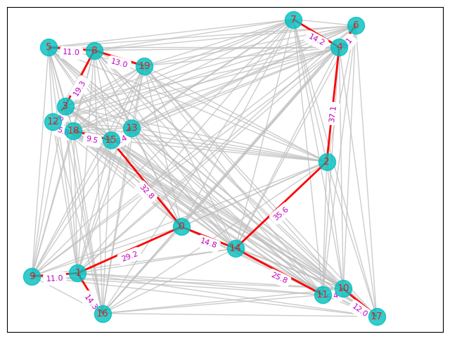

```python
fig, ax = plt.subplots(figsize=(8, 6))
node_pos = nx.get_node_attributes(G2, 'pos')  # 顶点位置
nx.draw(G2,node_pos,with_labels=True,node_color='c',edge_color='silver',node_size=300,font_size=10,font_color='r',alpha=0.8)  # 绘制无向图
# nx.draw_networkx_labels(G2, node_pos, labels=node_pos, font_size=6, horizontalalignment='left', verticalalignment='top')  # 绘制顶点属性：位置坐标 pos
# edge_col = ['red' if edge in T.edges() else 'silver' for edge in G2.edges()]  # 设置边的颜色
# nx.draw_networkx_edges(G2, node_pos, edge_color=edge_col, width=2)  # 设置指定边的颜色
nx.draw_networkx_edges(G2, node_pos, edgelist=T.edges, edge_color='r', width=2)  # 设置指定边的颜色
edge_weight = nx.get_edge_attributes(T, 'weight')  # 边的权值
nx.draw_networkx_edge_labels(T, node_pos, edge_labels=edge_weight, font_size=8, font_color='m', verticalalignment='top')  # 显示边的权值
plt.axis('on')  # Remove the axis
plt.xlim(-5, 100)
plt.ylim(-5, 100)
plt.show()
```

**参考文献**

- youcans Python小白的数学建模课 https://www.zhihu.com/column/c_1381900867424075776
- 司守奎 的 《Python数学实验与建模》